# Coral Colony Matrix Population Model

```r
s_set_branch <- s_set
```

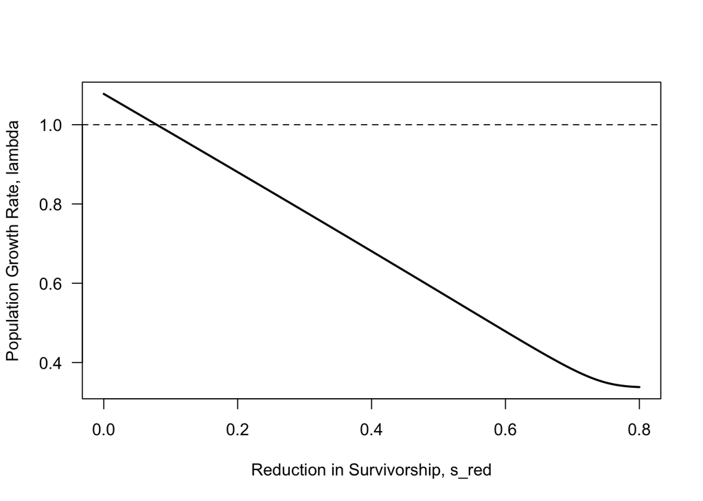

```r
# Massive corals
s_set <- seq(from = 0, to = s_min_mass, length.out = 300)

lambda_s_mass <- NaN*s_set # growth rate
mean_area_s_mass <- lambda_s_mass # mean colony size (planar area, cm2)
mean_rad_s_mass <- lambda_s_mass # mean colony radius (cm)
ss_s_mass <- matrix(rep(NaN,length(r_set_mass)*length(s_set)),nrow=length(s_set),ncol=length(r_set_mass))
ss_s_5class_mass <- matrix(rep(NaN,5*length(s_set)),nrow=length(s_set),ncol=5) # 5-class stage structure

for(ctr in 1:length(s_set)){
  s <- s_set[ctr]
# Creating survival matrix for massive corals
S <- matrix(rep(0,length(r_set_mass)^2),nrow=length(r_set_mass),ncol=length(r_set_mass))
S[2,2] <- s_R_mass # Survival of recruits
for(i in 3:length(r_set_mass)){ # For all corals of detectable size
  S[i,i] <- (s_max_mass-s_min_mass)*(1-exp(-b_mass*a_set_mass[i]))+s_min_mass-s  # compute the appropriate survivorship
}

# Transition matrix A *** EXCEPT *** for recruitment s_L
A <- F_mass + (G_mass%*%(diag(length(r_set_mass))-M_mass)+P_mass%*%M_mass)%*%S
A[2,1] <- s_L_mass

# Compute the leading eigenvalue (growth rate) and its eigenvector (stable stage distribution)
lambda_s_mass[ctr] <- Re(eigen(A)$values[1]) # leading eigenvalue
ss <- Re(eigen(A)$vectors[,1]); ss_s_mass[ctr,] <- ss/sum(ss) # stable stage distribution
mean_area_s_mass[ctr] <- sum(ss[3:length(ss)]/sum(ss[3:length(ss)])*a_set_mass[3:length(a_set_mass)]) # mean planar area of corals that are not larvae or new recruits
mean_rad_s_mass[ctr] <- sqrt(mean_area_s_mass[j]/pi) # mean radius of corals that are not larvae or new recruits

ss_s_5class_mass[ctr,] <- cum.dens(ss)

}


plot(s_set,lambda_s_mass, type='l',lwd=2,las=1,ylab='Population Growth Rate, lambda',xlab='Reduction in Survivorship, s_red'); abline(h=1,lty=2)
```

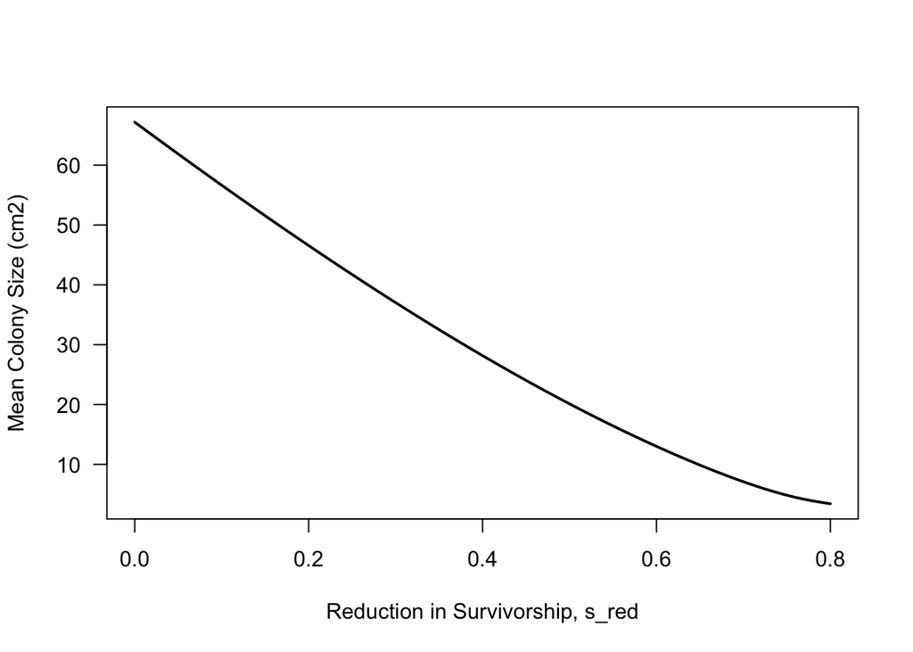

```r
plot(s_set,mean_area_s_mass,type='l',lwd=2,las=1,ylab='Mean Colony Size (cm2)',xlab='Reduction in Survivorship, s_red')
```

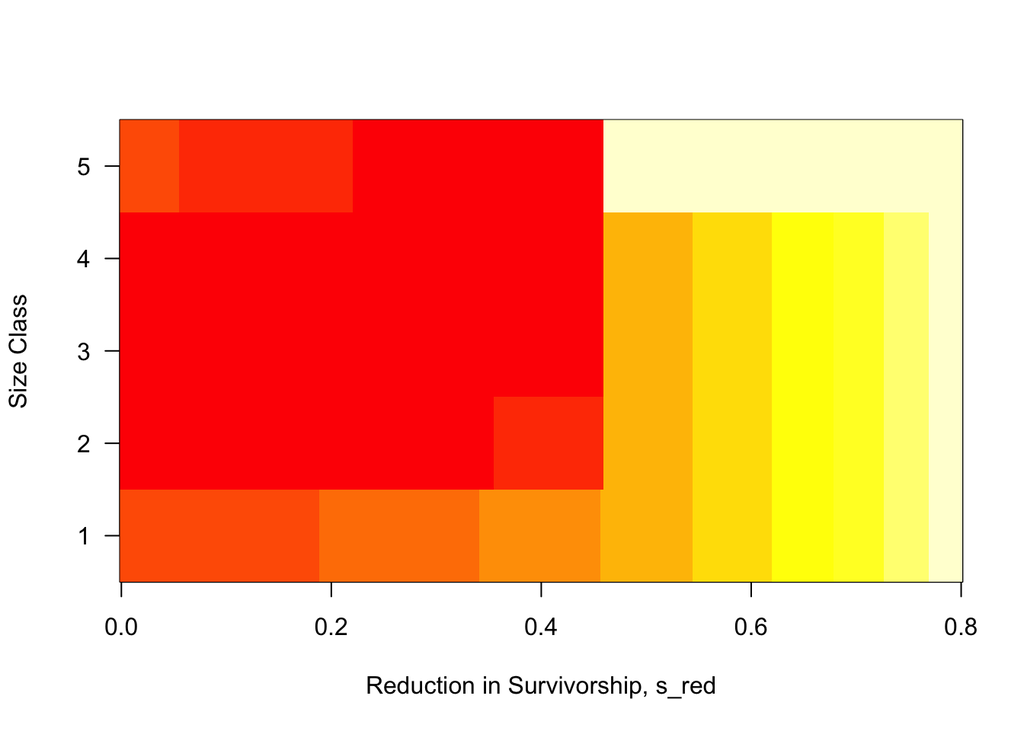

```r
image(s_set,c(1:5),(ss_s_5class_mass),las=1,ylab='Size Class',xlab='Reduction in Survivorship, s_red')
```

```r
s_set_mass <- s_set
```

#### Decreased Growth

Even when the stresses described above are sub-lethal, they are likely to reduce the growth rate (e.g., rate of linear extension) of a head of coral.

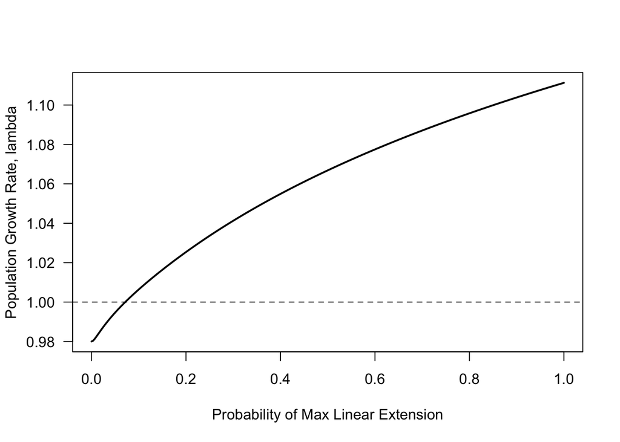

```r
# Branching corals
g_prob_set <- seq(from = 0, to = 1, length.out = 300)

lambda_g_branch <- NaN*g_prob_set # growth rate
mean_area_g_branch <- lambda_g_branch # mean colony size (planar area, cm2)
mean_rad_g_branch <- lambda_g_branch # mean colony radius (cm)
ss_g_branch <- matrix(rep(NaN,length(r_set_branch)*length(g_prob_set)),nrow=length(g_prob_set),ncol=length(r_set_branch))
ss_g_5class_branch <- matrix(rep(NaN,5*length(g_prob_set)),nrow=length(g_prob_set),ncol=5) # 5-class stage structure

for(ctr in 1:length(g_prob_set)){
  g_prob <- g_prob_set[ctr]



  # Creating growth matrix for massive corals
growthrad <- r_set_branch + g_branch
classgrowth <- NaN*classnum
for(i in 2:length(r_set_branch)){ # Class number to which a coral grows
  classgrowth[i] <- classnum[i]
  for(j in 1:length(r_set_branch)){ if(r_set_branch[j]*.999<=growthrad[i]){classgrowth[i] <- classnum[j]}  } # 0.999 multiplier is there because of rounding errors that sometimes are too conservative.
}

G <- matrix(rep(0,length(r_set_branch)^2),nrow=length(r_set_branch),ncol=length(r_set_branch)) # Growth matrix
for(i in 3:length(r_set_branch)){ # skip the larval and recruit stage
  G[classgrowth[i],i] <- g_prob # probability of growing to the largest class
  # Then, divide up the remaining probability amongst the other classes
  number.classes.poss <- classgrowth[i]-classnum[i]   # compute the number of classes you could grow in one step
  if(number.classes.poss > 0){
  prob.per.class <- (1-g_prob) / number.classes.poss # evenly distribute the probability of not achieving maximal growth amongst these classes
  for(j in 1:number.classes.poss){G[i-1+j,i] <- prob.per.class}}}
  if(number.classes.poss < 1){# If there's only one class to grow into, you move to it 100% of the time
    G[classgrowth[i],i] <- 1  }
G[3,2] <- g_rec_branch # All recruits grow at a fixed probability into a detectable size class
G[2,2] <- 1 - g_rec_branch # Recruits that don't grow to the next size class stay behind as recruits



# Transition matrix A *** EXCEPT *** for recruitment s_L
A <- F_branch + (G%*%(diag(length(r_set_branch))-M_branch)+P_branch%*%M_branch)%*%S_branch
A[2,1] <- s_L_branch

# Compute the leading eigenvalue (growth rate) and its eigenvector (stable stage distribution)
lambda_g_branch[ctr] <- Re(eigen(A)$values[1]) # leading eigenvalue
ss <- Re(eigen(A)$vectors[,1]); ss_g_branch[ctr,] <- ss/sum(ss) # stable stage distribution
mean_area_g_branch[ctr] <- sum(ss[3:length(ss)]/sum(ss[3:length(ss)])*a_set_branch[3:length(a_set_branch)]) # mean planar area of corals that are not larvae or new recruits
mean_rad_g_branch[ctr] <- sqrt(mean_area_g_branch[j]/pi) # mean radius of corals that are not larvae or new recruits

# Re-cluster into 5 size classes
ss_g_5class_branch[ctr,] <- cum.dens(ss)

}


plot(g_prob_set,lambda_g_branch, type='l',lwd=2,las=1,ylab='Population Growth Rate, lambda',xlab='Probability of Max Linear Extension'); abline(h=1,lty=2)
```

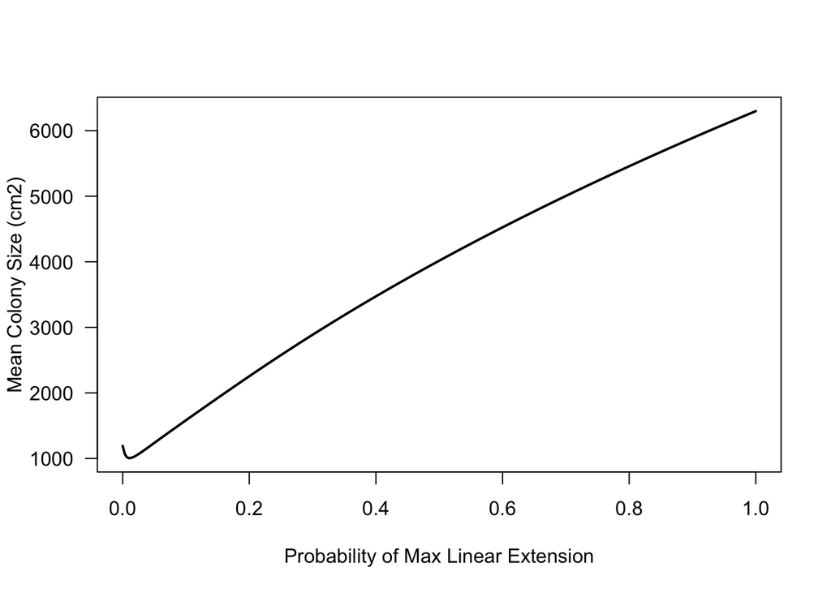

```r
plot(g_prob_set,mean_area_g_branch,type='l',lwd=2,las=1,ylab='Mean Colony Size (cm2)',xlab='Probability of Max Linear Extension')
```

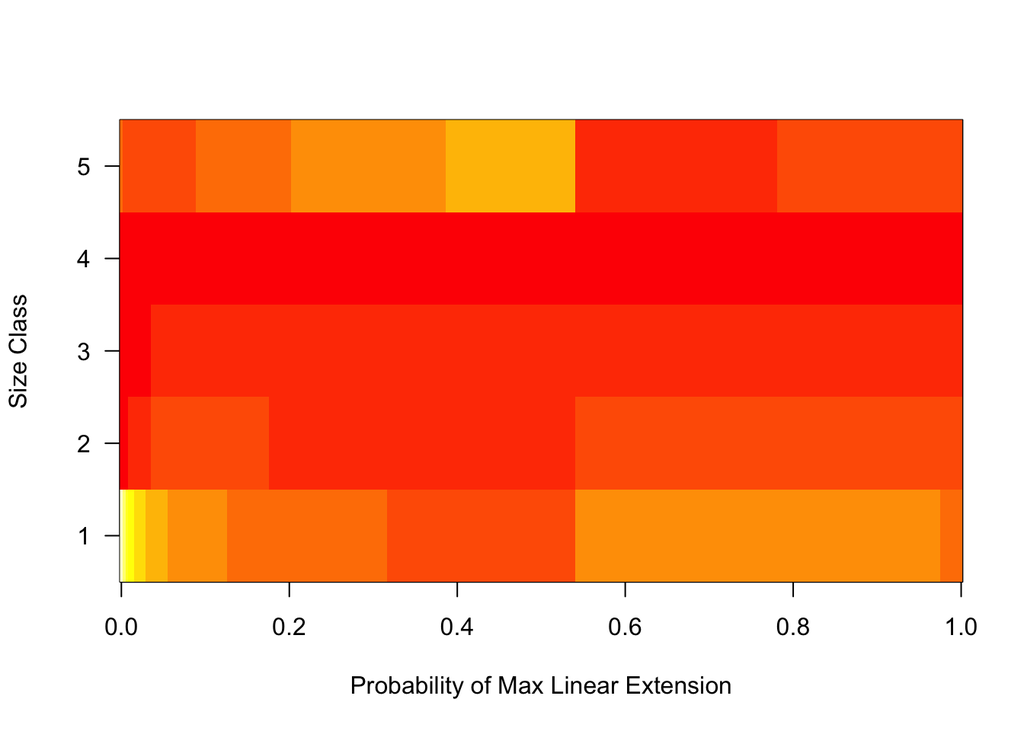

```r
image(g_prob_set,c(1:5),(ss_g_5class_branch),las=1,ylab='Size Class',xlab='Probability of Max Linear Extension')
```

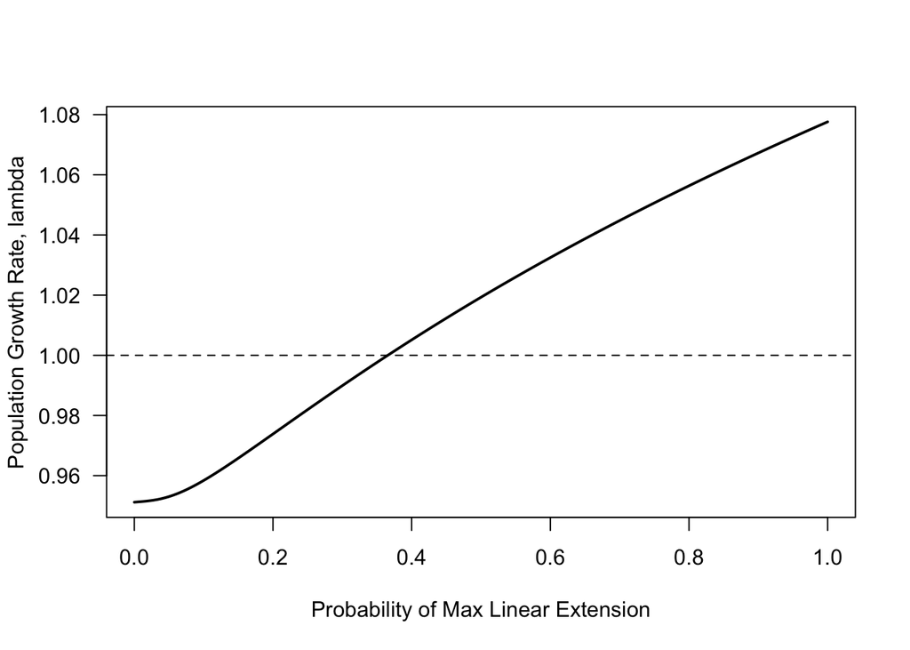

```r
# Branching corals
g_prob_set <- seq(from = 0, to = 1, length.out = 300)

lambda_g_mass <- NaN*g_prob_set # growth rate
mean_area_g_mass <- lambda_g_mass # mean colony size (planar area, cm2)
mean_rad_g_mass <- lambda_g_mass # mean colony radius (cm)
ss_g_mass <- matrix(rep(NaN,length(r_set_mass)*length(g_prob_set)),nrow=length(g_prob_set),ncol=length(r_set_mass))
ss_g_5class_mass <- matrix(rep(NaN,5*length(g_prob_set)),nrow=length(g_prob_set),ncol=5) # 5-class stage structure

for(ctr in 1:length(g_prob_set)){
  g_prob <- g_prob_set[ctr]

  # Creating growth matrix for massive corals
growthrad <- r_set_mass + g_mass
classgrowth <- NaN*classnum
for(i in 2:length(r_set_mass)){ # Class number to which a coral grows
  classgrowth[i] <- classnum[i]
  for(j in 1:length(r_set_mass)){ if(r_set_mass[j]*.999<=growthrad[i]){classgrowth[i] <- classnum[j]}  } # 0.999 multiplier is there because of rounding errors that sometimes are too conservative.
}

G <- matrix(rep(0,length(r_set_mass)^2),nrow=length(r_set_mass),ncol=length(r_set_mass)) # Growth matrix
for(i in 3:length(r_set_mass)){ # skip the larval and recruit stage
  G[classgrowth[i],i] <- g_prob # probability of growing to the largest class
  # Then, divide up the remaining probability amongst the other classes
  number.classes.poss <- classgrowth[i]-classnum[i]   # compute the number of classes you could grow in one step
  if(number.classes.poss > 0){
  prob.per.class <- (1-g_prob) / number.classes.poss # evenly distribute the probability of not achieving maximal growth amongst these classes
  for(j in 1:number.classes.poss){G[i-1+j,i] <- prob.per.class}}}
  if(number.classes.poss < 1){# If there's only one class to grow into, you move to it 100% of the time
    G[classgrowth[i],i] <- 1  }
G[3,2] <- g_rec_mass # All recruits grow at a fixed probability into a detectable size class
G[2,2] <- 1 - g_rec_mass # Recruits that don't grow to the next size class stay behind as recruits



# Transition matrix A *** EXCEPT *** for recruitment s_L
A <- F_mass + (G%*%(diag(length(r_set_mass))-M_mass)+P_mass%*%M_mass)%*%S_mass
A[2,1] <- s_L_mass

# Compute the leading eigenvalue (growth rate) and its eigenvector (stable stage distribution)
lambda_g_mass[ctr] <- Re(eigen(A)$values[1]) # leading eigenvalue
ss <- Re(eigen(A)$vectors[,1]); ss_g_mass[ctr,] <- ss/sum(ss) # stable stage distribution
mean_area_g_mass[ctr] <- sum(ss[3:length(ss)]/sum(ss[3:length(ss)])*a_set_mass[3:length(a_set_mass)]) # mean planar area of corals that are not larvae or new recruits
mean_rad_g_mass[ctr] <- sqrt(mean_area_g_mass[j]/pi) # mean radius of corals that are not larvae or new recruits

# Re-cluster into 5 size classes
ss_g_5class_mass[ctr,] <- cum.dens(ss)

}


plot(g_prob_set,lambda_g_mass, type='l',lwd=2,las=1,ylab='Population Growth Rate, lambda',xlab='Probability of Max Linear Extension'); abline(h=1,lty=2)
```

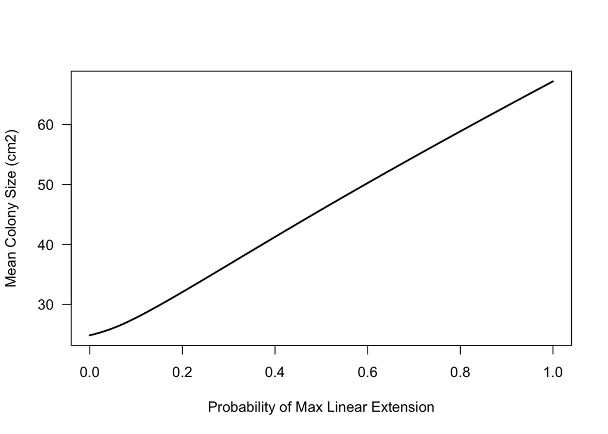

```r
plot(g_prob_set,mean_area_g_mass,type='l',lwd=2,las=1,ylab='Mean Colony Size (cm2)',xlab='Probability of Max Linear Extension')
```

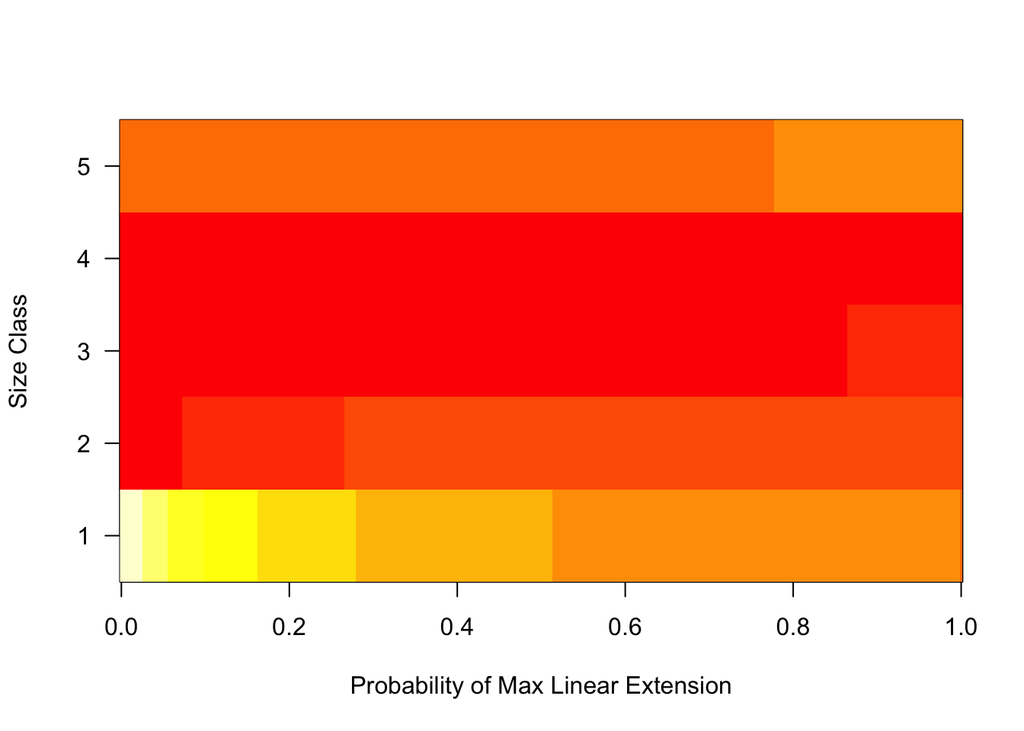

```r
image(g_prob_set,c(1:5),(ss_g_5class_mass),las=1,ylab='Size Class',xlab='Probability of Max Linear Extension')
```

#### Reduced Fecundity

Stressed corals may have reduced energetic stores to invest in reproduction. The consequent reductions in fecundity drive reductions in population growth rate, although corals tend to shift towards larger mean size. This is due to a reduction in the production of new recruits.

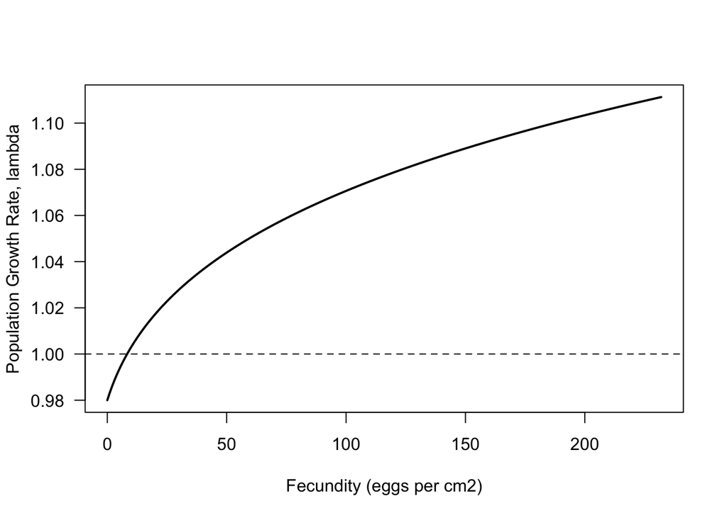

```r
# Branching corals
p_set_branch <- seq(from = 0, to = p_branch, length.out = 300)

lambda_p_branch <- NaN*p_set_branch # growth rate
mean_area_p_branch <- lambda_p_branch # mean colony size (planar area, cm2)
mean_rad_p_branch <- lambda_p_branch # mean colony radius (cm)
ss_p_branch <- matrix(rep(NaN,length(r_set_branch)*length(p_set_branch)),nrow=length(p_set_branch),ncol=length(r_set_branch))
ss_p_5class_branch <- matrix(rep(NaN,5*length(p_set_branch)),nrow=length(p_set_branch),ncol=5) # 5-class stage structure

for(ctr in 1:length(p_set_branch)){
  p <- p_set_branch[ctr]

  # Creating fecundity matrix for branching corals
F <- matrix(rep(0,length(r_set_branch)^2),nrow=length(r_set_branch),ncol=length(r_set_branch)) # fecundity matrix
for(i in 1:length(r_set_branch)){
  if(a_set_branch[i] > a_f_branch){ # if a coral in this size class is large enough to reproduce
    F[1,i] <- a_set_branch[i]*p
  }
}


# Transition matrix A *** EXCEPT *** for recruitment s_L
A <- F + (G_branch%*%(diag(length(r_set_branch))-M_branch)+P_branch%*%M_branch)%*%S_branch
A[2,1] <- s_L_branch

# Compute the leading eigenvalue (growth rate) and its eigenvector (stable stage distribution)
lambda_p_branch[ctr] <- Re(eigen(A)$values[1]) # leading eigenvalue
ss <- Re(eigen(A)$vectors[,1]); ss_p_branch[ctr,] <- ss/sum(ss) # stable stage distribution
mean_area_p_branch[ctr] <- sum(ss[3:length(ss)]/sum(ss[3:length(ss)])*a_set_branch[3:length(a_set_branch)]) # mean planar area of corals that are not larvae or new recruits
mean_rad_p_branch[ctr] <- sqrt(mean_area_p_branch[j]/pi) # mean radius of corals that are not larvae or new recruits

# Re-cluster into 5 size classes
ss_p_5class_branch[ctr,] <- cum.dens(ss)

}


plot(p_set_branch,lambda_p_branch, type='l',lwd=2,las=1,ylab='Population Growth Rate, lambda',xlab='Fecundity (eggs per cm2)'); abline(h=1,lty=2)
```

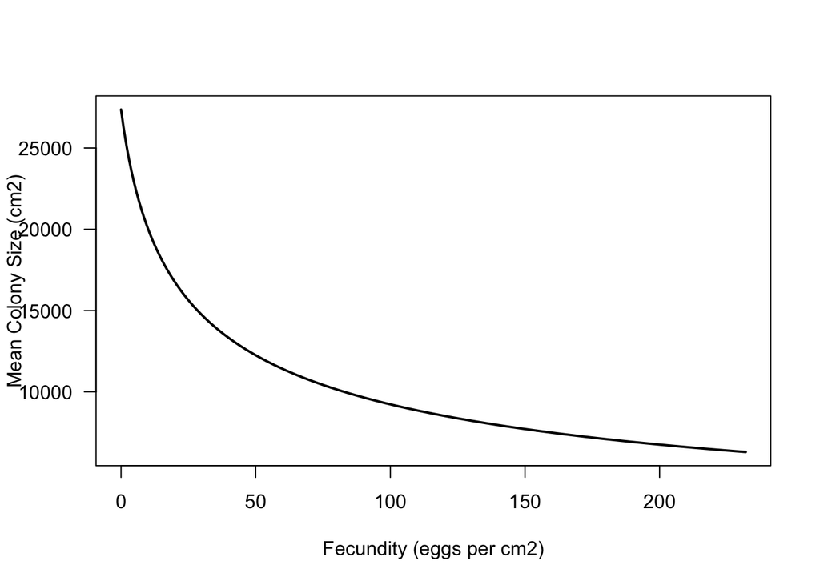

```r
plot(p_set_branch,mean_area_p_branch,type='l',lwd=2,las=1,ylab='Mean Colony Size (cm2)',xlab='Fecundity (eggs per cm2)')
```

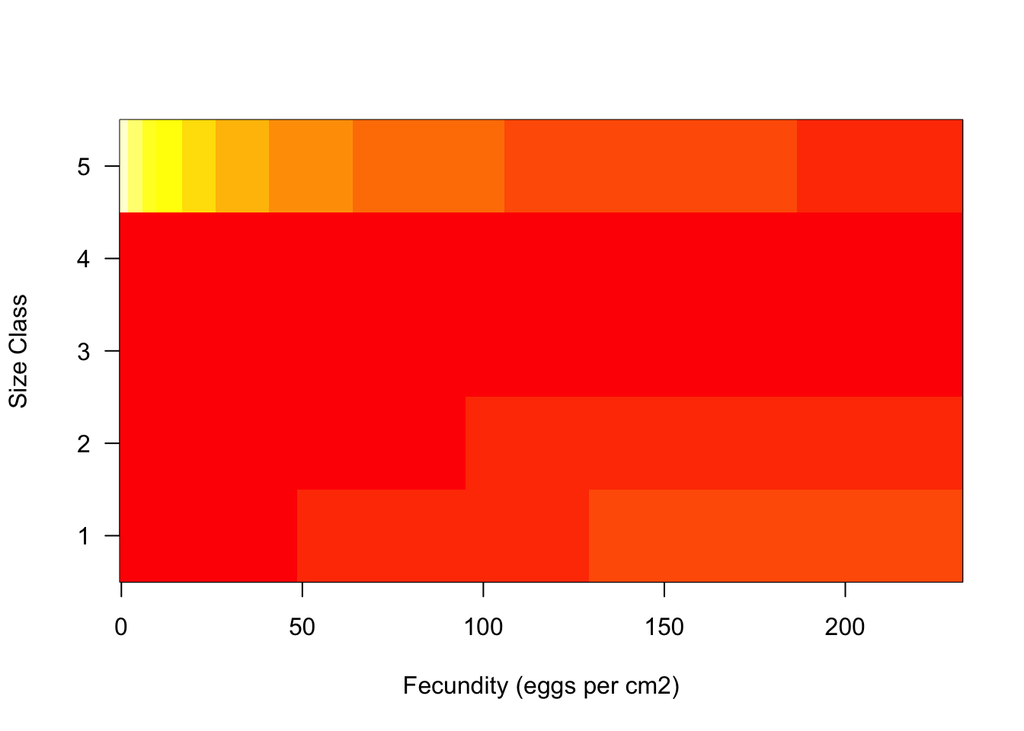

```r
image(p_set_branch,c(1:5),(ss_p_5class_branch),las=1,ylab='Size Class',xlab='Fecundity (eggs per cm2)')
```

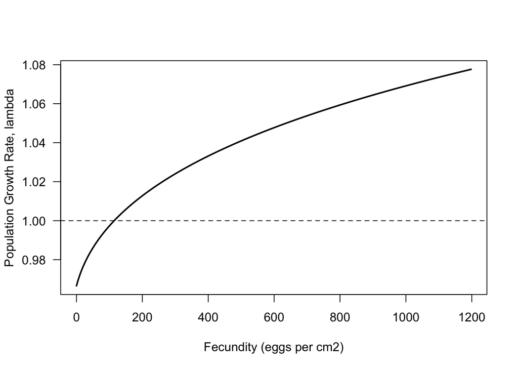

```r
# Massive corals
p_set_mass <- seq(from = 0, to = p_mass, length.out = 300)

lambda_p_mass <- NaN*p_set_mass # growth rate
mean_area_p_mass <- lambda_p_mass # mean colony size (planar area, cm2)
mean_rad_p_mass <- lambda_p_mass # mean colony radius (cm)
ss_p_mass <- matrix(rep(NaN,length(r_set_mass)*length(p_set_mass)),nrow=length(p_set_mass),ncol=length(r_set_mass))
ss_p_5class_mass <- matrix(rep(NaN,5*length(p_set_mass)),nrow=length(p_set_mass),ncol=5) # 5-class stage structure

for(ctr in 1:length(p_set_mass)){
  p <- p_set_mass[ctr]

  # Creating fecundity matrix for branching corals
F <- matrix(rep(0,length(r_set_mass)^2),nrow=length(r_set_mass),ncol=length(r_set_mass)) # fecundity matrix
for(i in 1:length(r_set_mass)){
  if(a_set_mass[i] > a_f_mass){ # if a coral in this size class is large enough to reproduce
    F[1,i] <- a_set_mass[i]*p
  }
}


# Transition matrix A *** EXCEPT *** for recruitment s_L
A <- F + (G_mass%*%(diag(length(r_set_mass))-M_mass)+P_mass%*%M_mass)%*%S_mass
A[2,1] <- s_L_mass

# Compute the leading eigenvalue (growth rate) and its eigenvector (stable stage distribution)
lambda_p_mass[ctr] <- Re(eigen(A)$values[1]) # leading eigenvalue
ss <- Re(eigen(A)$vectors[,1]); ss_p_mass[ctr,] <- ss/sum(ss) # stable stage distribution
mean_area_p_mass[ctr] <- sum(ss[3:length(ss)]/sum(ss[3:length(ss)])*a_set_mass[3:length(a_set_mass)]) # mean planar area of corals that are not larvae or new recruits
mean_rad_p_mass[ctr] <- sqrt(mean_area_p_mass[j]/pi) # mean radius of corals that are not larvae or new recruits

# Re-cluster into 5 size classes
ss_p_5class_mass[ctr,] <- cum.dens(ss)

}


plot(p_set_mass,lambda_p_mass, type='l',lwd=2,las=1,ylab='Population Growth Rate, lambda',xlab='Fecundity (eggs per cm2)'); abline(h=1,lty=2)
```

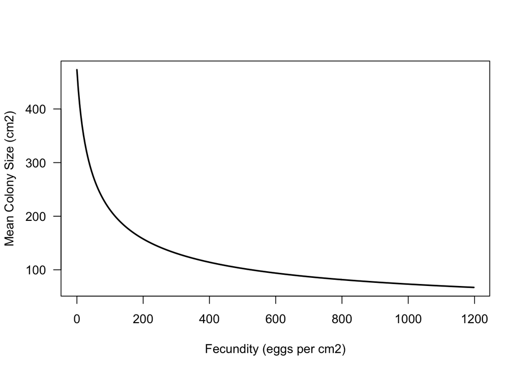

```r
plot(p_set_mass,mean_area_p_mass,type='l',lwd=2,las=1,ylab='Mean Colony Size (cm2)',xlab='Fecundity (eggs per cm2)')
```

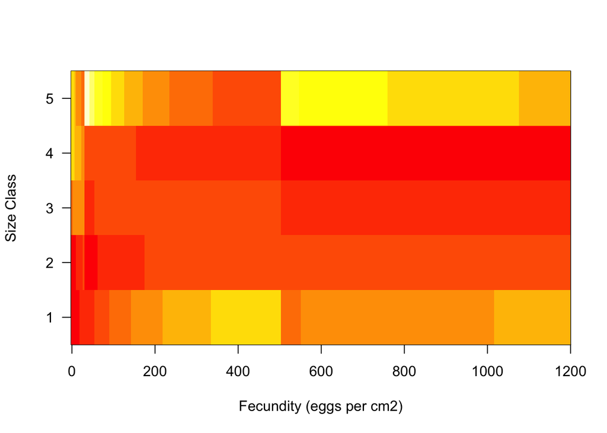

```r
image(p_set_mass,c(1:5),(ss_p_5class_mass),las=1,ylab='Size Class',xlab='Fecundity (eggs per cm2)')
```

#### Composite figure

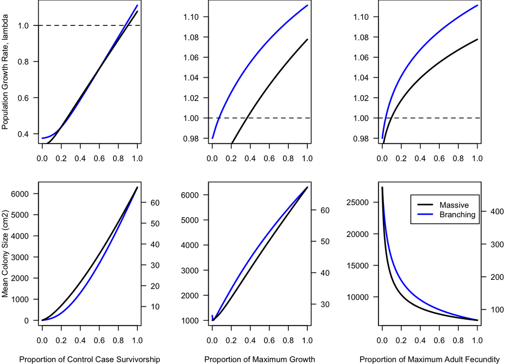

```r
par(mfrow=c(2,3),mar=c(4,4,0,3))

plot((s_min_branch - s_set_branch)/s_min_branch,lambda_s_branch, type='l',lwd=2,las=1,col='blue',ylab='Population Growth Rate, lambda',xlab=''); lines((s_min_mass - s_set_mass)/s_min_mass,lambda_s_mass,lwd=2); abline(h=1,lty=2)
plot(g_prob_set,lambda_g_branch, type='l',lwd=2,las=1,col='blue',ylab='',xlab=''); lines(g_prob_set,lambda_g_mass,lwd=2); abline(h=1,lty=2)
plot(p_set_branch/p_branch,lambda_p_branch, type='l',lwd=2,las=1,ylab='',xlab='',col='blue'); lines(p_set_mass/p_mass,lambda_p_mass,lwd=2); abline(h=1,lty=2)

plot((s_min_branch - s_set_branch)/s_min_branch,mean_area_s_branch,type='l',lwd=2,las=1,col='blue',ylab='Mean Colony Size (cm2)',xlab='Proportion of Control Case Survivorship',axes=FALSE); axis(2,pretty(range(mean_area_s_branch)),las=1); par(new=TRUE); plot((s_min_mass-s_set_mass)/s_min_mass,mean_area_s_mass,type='l',lwd=2,axes=FALSE,xlab='',ylab=''); axis(4,pretty(range(mean_area_s_mass)),las=1); axis(1,pretty(range((s_min_branch - s_set_branch)/s_min_branch))); box()
plot(g_prob_set,mean_area_g_branch,type='l',lwd=2,las=1,col='blue',ylab='',xlab='Proportion of Maximum Growth',axes=FALSE); axis(2,pretty(range(mean_area_g_branch)),las=1); par(new=TRUE); plot(g_prob_set,mean_area_g_mass,type='l',lwd=2,axes=FALSE,xlab='',ylab=''); axis(4,pretty(range(mean_area_g_mass)),las=1); axis(1,pretty(range(g_prob_set))); box()
plot(p_set_branch/p_branch,mean_area_p_branch,type='l',lwd=2,las=1,col='blue',ylab='',xlab='Proportion of Maximum Adult Fecundity',axes=FALSE); axis(2,pretty(range(mean_area_p_branch)),las=1); par(new=TRUE); plot(p_set_mass/p_mass,mean_area_p_mass,type='l',lwd=2,axes=FALSE,xlab='',ylab=''); axis(4,pretty(range(mean_area_p_mass)),las=1); axis(1,pretty(range(p_set_branch/p_branch))); box(); legend(.3,450,legend=c('Massive','Branching'),lwd=2,col=c('black','blue'))
```

#### Demographic Trends May Indicate Changes to Vital Rates

Our model predicts some distinct “signatures” to the changes in population structure caused by shifts in each coral vital rate. Although not all altered population structures may be statistically distinguishable from one another, our results highlight the importance of coral demographic data (in particular, data on shifts in coral colony size over time) to determining population status and assessing population viability.

While stable stage distributions may be most distinctive and informative, in reality it can take several years of stable environmental conditions for coral populations to equilibrate at these size distributions. Therefore, we examine the trajectories of populations that have recently experienced a change in a demographic parameter (e.g., an increase in mortality, decrease in growth, or decrease in fecundity) over short and long timescales by comparing the emerging size distributions to the stable stage distributions before (i.e., baseline parameters) and after (i.e., with new vital rates) shifts in these demographic parameters.

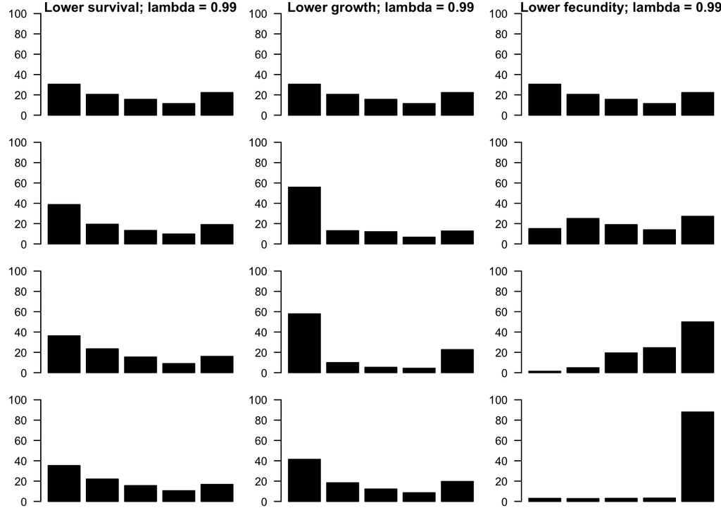

```r
### Branching Corals ###
## Control Case:
# A_branch is the projection matrix
# ss_branch_ctrl is the stable stage distribution
# lambda_branch_ctrl is the leading eigenvalue
# ss_cum_branch_ctrl is the 5-stage stage distribution

## Reduced survivorship
s_red_branch <- s_min_branch/7.24

# Creating survival matrix for branching corals
S <- matrix(rep(0,length(r_set_branch)^2),nrow=length(r_set_branch),ncol=length(r_set_branch))
S[2,2] <- s_R_branch # Survival of recruits
for(i in 3:length(r_set_branch)){ # For all corals of detectable size
  S[i,i] <- (s_max_branch-s_min_branch)*(1-exp(-b_branch*a_set_branch[i]))+s_min_branch-s_red_branch  # compute the appropriate survivorship
}

# Transition matrix A
A_red_s_branch <- F_branch + (G_branch%*%(diag(length(r_set_branch))-M_branch)+P_branch%*%M_branch)%*%S
A_red_s_branch[2,1] <- s_L_branch

# Metrics
lambda_branch_red_s <- Re(eigen(A_red_s_branch)$values[1])
ss_red_s_branch <- Re(eigen(A_red_s_branch)$vectors[,1]); ss_red_s_branch <- ss_red_s_branch/sum(ss_red_s_branch)
ss_cum_red_s_branch <- cum.dens(ss_red_s_branch)


## Reduced growth
g_red_branch <- .0335

# Creating growth matrix for branching corals
growthrad <- r_set_branch + g_branch
classgrowth <- NaN*classnum
for(i in 2:length(r_set_branch)){ # Class number to which a coral grows
  classgrowth[i] <- classnum[i]
  for(j in 1:length(r_set_branch)){ if(r_set_branch[j]*.999<=growthrad[i]){classgrowth[i] <- classnum[j]}  } # 0.999 multiplier is there because of rounding errors that sometimes are too conservative.
}

G <- matrix(rep(0,length(r_set_branch)^2),nrow=length(r_set_branch),ncol=length(r_set_branch)) # Growth matrix
for(i in 3:length(r_set_branch)){ # skip the larval and recruit stage
  G[classgrowth[i],i] <- g_red_branch # probability of growing to the largest class
  # Then, divide up the remaining probability amongst the other classes
  number.classes.poss <- classgrowth[i]-classnum[i]   # compute the number of classes you could grow in one step
  if(number.classes.poss > 0){
  prob.per.class <- (1-g_red_branch) / number.classes.poss # evenly distribute the probability of not achieving maximal growth amongst these classes
  for(j in 1:number.classes.poss){G[i-1+j,i] <- prob.per.class}}}
  if(number.classes.poss < 1){# If there's only one class to grow into, you move to it 100% of the time
    G[classgrowth[i],i] <- 1  }
G[3,2] <- g_rec_branch # All recruits grow at a fixed probability into a detectable size class
G[2,2] <- 1 - g_rec_branch # Recruits that don't grow to the next size class stay behind as recruits

# Transition matrix A
A_red_g_branch <- F_branch + (G%*%(diag(length(r_set_branch))-M_branch)+P_branch%*%M_branch)%*%S_branch
A_red_g_branch[2,1] <- s_L_branch

# Metrics
lambda_branch_red_g <- Re(eigen(A_red_g_branch)$values[1])
ss_red_g_branch <- Re(eigen(A_red_g_branch)$vectors[,1]); ss_red_g_branch <- ss_red_g_branch/sum(ss_red_g_branch)
ss_cum_red_g_branch <- cum.dens(ss_red_g_branch)


## Reduced fecundity
p_red_branch <- p_branch/65.5

# Creating fecundity matrix for branching corals
F <- matrix(rep(0,length(r_set_branch)^2),nrow=length(r_set_branch),ncol=length(r_set_branch)) # fecundity matrix
for(i in 1:length(r_set_branch)){
  if(a_set_branch[i] > a_f_branch){ # if a coral in this size class is large enough to reproduce
    F[1,i] <- a_set_branch[i]*p_red_branch
  }
}

# Transition matrix A
A_red_p_branch <- F + (G_branch%*%(diag(length(r_set_branch))-M_branch)+P_branch%*%M_branch)%*%S_branch
A_red_p_branch[2,1] <- s_L_branch

# Metrics
lambda_branch_red_p <- Re(eigen(A_red_p_branch)$values[1])
ss_red_p_branch <- Re(eigen(A_red_p_branch)$vectors[,1]); ss_red_p_branch <- ss_red_p_branch/sum(ss_red_p_branch)
ss_cum_red_p_branch <- cum.dens(ss_red_p_branch)




# Simulate 100 years of time
years <- 50
ss_ctrl_set_branch <- matrix(rep(NaN,(years+1)*length(r_set_branch)),ncol=(years+1),nrow=length(r_set_branch))
ss_ctrl_set_branch[,1] <- ss_branch_ctrl
ss_s_set_branch <- ss_ctrl_set_branch
ss_g_set_branch <- ss_ctrl_set_branch
ss_p_set_branch <- ss_ctrl_set_branch

mean_area_ctrl_set_branch <- rep(NaN,years+1)
mean_area_ctrl_set_branch[1] <- sum(ss_branch_ctrl[3:length(ss_branch_ctrl)]/sum(ss_branch_ctrl[3:length(ss_branch_ctrl)])*a_set_branch[3:length(a_set_branch)])
mean_area_s_set_branch <- mean_area_ctrl_set_branch
mean_area_g_set_branch <- mean_area_ctrl_set_branch
mean_area_p_set_branch <- mean_area_ctrl_set_branch

ss_cum_ctrl_set_branch <- matrix(rep(NaN,(years+1)*5),ncol=(years+1),nrow=5)
ss_cum_s_set_branch <- ss_cum_ctrl_set_branch
ss_cum_g_set_branch <- ss_cum_ctrl_set_branch
ss_cum_p_set_branch <- ss_cum_ctrl_set_branch


# Simulate the progression of the size distribution, starting from the control case

for(i in 1:years){
  ss_ctrl_set_branch[,i+1] <- A_branch%*%ss_ctrl_set_branch[,i]
  ss_ctrl_set_branch[,i+1] <- ss_ctrl_set_branch[,i+1] / sum(ss_ctrl_set_branch[,i+1])

  ss_s_set_branch[,i+1] <- A_red_s_branch%*%ss_s_set_branch[,i]
  ss_s_set_branch[,i+1] <- ss_s_set_branch[,i+1] / sum(ss_s_set_branch[,i+1])

  ss_g_set_branch[,i+1] <- A_red_g_branch%*%ss_g_set_branch[,i]
  ss_g_set_branch[,i+1] <- ss_g_set_branch[,i+1] / sum(ss_g_set_branch[,i+1])

  ss_p_set_branch[,i+1] <- A_red_p_branch%*%ss_p_set_branch[,i]
  ss_p_set_branch[,i+1] <- ss_p_set_branch[,i+1] / sum(ss_p_set_branch[,i+1])


  ss_cum_ctrl_set_branch[,i+1] <- cum.dens(ss_ctrl_set_branch[,i+1])
  ss_cum_s_set_branch[,i+1] <- cum.dens(ss_s_set_branch[,i+1])
  ss_cum_g_set_branch[,i+1] <- cum.dens(ss_g_set_branch[,i+1])
  ss_cum_p_set_branch[,i+1] <- cum.dens(ss_p_set_branch[,i+1])

  mean_area_ctrl_set_branch[i+1] <- sum(ss_ctrl_set_branch[3:length(a_set_branch),i+1]/sum(ss_ctrl_set_branch[3:length(a_set_branch),i+1])*a_set_branch[3:length(a_set_branch)])
  mean_area_s_set_branch[i+1] <- sum(ss_s_set_branch[3:length(a_set_branch),i+1]/sum(ss_s_set_branch[3:length(a_set_branch),i+1])*a_set_branch[3:length(a_set_branch)])
  mean_area_g_set_branch[i+1] <- sum(ss_g_set_branch[3:length(a_set_branch),i+1]/sum(ss_g_set_branch[3:length(a_set_branch),i+1])*a_set_branch[3:length(a_set_branch)])
  mean_area_p_set_branch[i+1] <- sum(ss_p_set_branch[3:length(a_set_branch),i+1]/sum(ss_p_set_branch[3:length(a_set_branch),i+1])*a_set_branch[3:length(a_set_branch)])

}




numyears_set <- c(5,10) # the years that will be plotted

par(mar=c(1,3,1,0),mfcol=c((2+length(numyears_set)),3))
# altered survival
barplot(ss_cum_branch_ctrl*100,las=1,ylim=c(0,100),col='black',main=paste('Lower survival; lambda = ',round(lambda_branch_red_s,4),sep=''))
for(i in 1:length(numyears_set)){
  barplot(ss_cum_s_set_branch[,numyears_set[i]]*100,las=1,ylim=c(0,100),col='black')
}
barplot(ss_cum_red_s_branch*100,las=1,ylim=c(0,100),col='black')


# altered growth
barplot(ss_cum_branch_ctrl*100,las=1,ylim=c(0,100),col='black',main=paste('Lower growth; lambda = ',round(lambda_branch_red_g,4),sep=''))
for(i in 1:length(numyears_set)){
  barplot(ss_cum_g_set_branch[,numyears_set[i]]*100,las=1,ylim=c(0,100),col='black')
}
barplot(ss_cum_red_g_branch*100,las=1,ylim=c(0,100),col='black')


# altered fecundity
barplot(ss_cum_branch_ctrl*100,las=1,ylim=c(0,100),col='black',main=paste('Lower fecundity; lambda = ',round(lambda_branch_red_p,4),sep=''))
for(i in 1:length(numyears_set)){
  barplot(ss_cum_p_set_branch[,numyears_set[i]]*100,las=1,ylim=c(0,100),col='black')
}
barplot(ss_cum_red_p_branch*100,las=1,ylim=c(0,100),col='black')
```

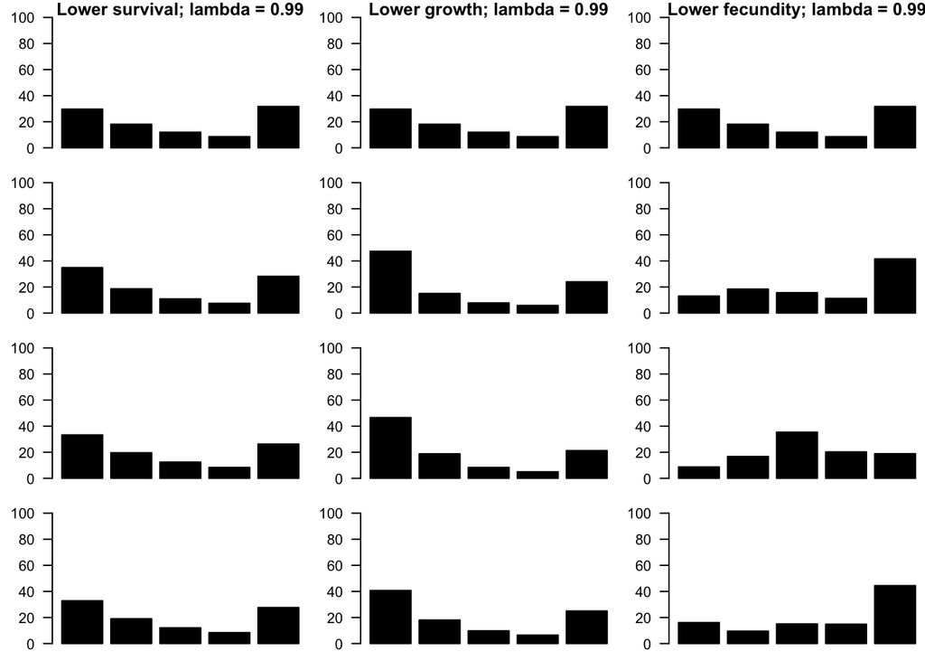

```r
### Massive Corals ###
## Control Case:
# A_mass is the projection matrix
# ss_mass_ctrl is the stable stage distribution
# lambda_mass_ctrl is the leading eigenvalue
# ss_cum_mass_ctrl is the 5-stage stage distribution

## Reduced survivorship
s_red_mass <- s_min_mass/8.99

# Creating survival matrix for massive corals
S <- matrix(rep(0,length(r_set_mass)^2),nrow=length(r_set_mass),ncol=length(r_set_mass))
S[2,2] <- s_R_mass # Survival of recruits
for(i in 3:length(r_set_mass)){ # For all corals of detectable size
  S[i,i] <- (s_max_mass-s_min_mass)*(1-exp(-b_mass*a_set_mass[i]))+s_min_mass-s_red_mass  # compute the appropriate survivorship
}

# Transition matrix A
A_red_s_mass <- F_mass + (G_mass%*%(diag(length(r_set_mass))-M_mass)+P_mass%*%M_mass)%*%S
A_red_s_mass[2,1] <- s_L_mass

# Metrics
lambda_mass_red_s <- Re(eigen(A_red_s_mass)$values[1])
ss_red_s_mass <- Re(eigen(A_red_s_mass)$vectors[,1]); ss_red_s_mass <- ss_red_s_mass/sum(ss_red_s_mass)
ss_cum_red_s_mass <- cum.dens(ss_red_s_mass)


## Reduced growth
g_red_mass <- .3008

# Creating growth matrix for massive corals
growthrad <- r_set_mass + g_mass
classgrowth <- NaN*classnum
for(i in 2:length(r_set_mass)){ # Class number to which a coral grows
  classgrowth[i] <- classnum[i]
  for(j in 1:length(r_set_mass)){ if(r_set_mass[j]*.999<=growthrad[i]){classgrowth[i] <- classnum[j]}  } # 0.999 multiplier is there because of rounding errors that sometimes are too conservative.
}

G <- matrix(rep(0,length(r_set_mass)^2),nrow=length(r_set_mass),ncol=length(r_set_mass)) # Growth matrix
for(i in 3:length(r_set_mass)){ # skip the larval and recruit stage
  G[classgrowth[i],i] <- g_red_mass # probability of growing to the largest class
  # Then, divide up the remaining probability amongst the other classes
  number.classes.poss <- classgrowth[i]-classnum[i]   # compute the number of classes you could grow in one step
  if(number.classes.poss > 0){
  prob.per.class <- (1-g_red_mass) / number.classes.poss # evenly distribute the probability of not achieving maximal growth amongst these classes
  for(j in 1:number.classes.poss){G[i-1+j,i] <- prob.per.class}}}
  if(number.classes.poss < 1){# If there's only one class to grow into, you move to it 100% of the time
    G[classgrowth[i],i] <- 1  }
G[3,2] <- g_rec_mass # All recruits grow at a fixed probability into a detectable size class
G[2,2] <- 1 - g_rec_mass # Recruits that don't grow to the next size class stay behind as recruits

# Transition matrix A
A_red_g_mass <- F_mass + (G%*%(diag(length(r_set_mass))-M_mass)+P_mass%*%M_mass)%*%S_mass
A_red_g_mass[2,1] <- s_L_mass

# Metrics
lambda_mass_red_g <- Re(eigen(A_red_g_mass)$values[1])
ss_red_g_mass <- Re(eigen(A_red_g_mass)$vectors[,1]); ss_red_g_mass <- ss_red_g_mass/sum(ss_red_g_mass)
ss_cum_red_g_mass <- cum.dens(ss_red_g_mass)


## Reduced fecundity
p_red_mass <- p_mass/18.3

# Creating fecundity matrix for massive corals
F <- matrix(rep(0,length(r_set_mass)^2),nrow=length(r_set_mass),ncol=length(r_set_mass)) # fecundity matrix
for(i in 1:length(r_set_mass)){
  if(a_set_mass[i] > a_f_mass){ # if a coral in this size class is large enough to reproduce
    F[1,i] <- a_set_mass[i]*p_red_mass
  }
}

# Transition matrix A
A_red_p_mass <- F + (G_mass%*%(diag(length(r_set_mass))-M_mass)+P_mass%*%M_mass)%*%S_mass
A_red_p_mass[2,1] <- s_L_mass

# Metrics
lambda_mass_red_p <- Re(eigen(A_red_p_mass)$values[1])
ss_red_p_mass <- Re(eigen(A_red_p_mass)$vectors[,1]); ss_red_p_mass <- ss_red_p_mass/sum(ss_red_p_mass)
ss_cum_red_p_mass <- cum.dens(ss_red_p_mass)



# Simulate 100 years of time
years <- 50
ss_ctrl_set_mass <- matrix(rep(NaN,(years+1)*length(r_set_mass)),ncol=(years+1),nrow=length(r_set_mass))
ss_ctrl_set_mass[,1] <- ss_mass_ctrl
ss_s_set_mass <- ss_ctrl_set_mass
ss_g_set_mass <- ss_ctrl_set_mass
ss_p_set_mass <- ss_ctrl_set_mass

mean_area_ctrl_set_mass <- rep(NaN,years+1)
mean_area_ctrl_set_mass[1] <- sum(ss_mass_ctrl[3:length(ss_mass_ctrl)]/sum(ss_mass_ctrl[3:length(ss_mass_ctrl)])*a_set_mass[3:length(a_set_mass)])
mean_area_s_set_mass <- mean_area_ctrl_set_mass
mean_area_g_set_mass <- mean_area_ctrl_set_mass
mean_area_p_set_mass <- mean_area_ctrl_set_mass

ss_cum_ctrl_set_mass <- matrix(rep(NaN,(years+1)*5),ncol=(years+1),nrow=5)
ss_cum_s_set_mass <- ss_cum_ctrl_set_mass
ss_cum_g_set_mass <- ss_cum_ctrl_set_mass
ss_cum_p_set_mass <- ss_cum_ctrl_set_mass


# Simulate the progression of the size distribution, starting from the control case

for(i in 1:years){
  ss_ctrl_set_mass[,i+1] <- A_mass%*%ss_ctrl_set_mass[,i]
  ss_ctrl_set_mass[,i+1] <- ss_ctrl_set_mass[,i+1] / sum(ss_ctrl_set_mass[,i+1])

  ss_s_set_mass[,i+1] <- A_red_s_mass%*%ss_s_set_mass[,i]
  ss_s_set_mass[,i+1] <- ss_s_set_mass[,i+1] / sum(ss_s_set_mass[,i+1])

  ss_g_set_mass[,i+1] <- A_red_g_mass%*%ss_g_set_mass[,i]
  ss_g_set_mass[,i+1] <- ss_g_set_mass[,i+1] / sum(ss_g_set_mass[,i+1])

  ss_p_set_mass[,i+1] <- A_red_p_mass%*%ss_p_set_mass[,i]
  ss_p_set_mass[,i+1] <- ss_p_set_mass[,i+1] / sum(ss_p_set_mass[,i+1])


  ss_cum_ctrl_set_mass[,i+1] <- cum.dens(ss_ctrl_set_mass[,i+1])
  ss_cum_s_set_mass[,i+1] <- cum.dens(ss_s_set_mass[,i+1])
  ss_cum_g_set_mass[,i+1] <- cum.dens(ss_g_set_mass[,i+1])
  ss_cum_p_set_mass[,i+1] <- cum.dens(ss_p_set_mass[,i+1])

  mean_area_ctrl_set_mass[i+1] <- sum(ss_ctrl_set_mass[3:length(a_set_mass),i+1]/sum(ss_ctrl_set_mass[3:length(a_set_mass),i+1])*a_set_mass[3:length(a_set_mass)])
  mean_area_s_set_mass[i+1] <- sum(ss_s_set_mass[3:length(a_set_mass),i+1]/sum(ss_s_set_mass[3:length(a_set_mass),i+1])*a_set_mass[3:length(a_set_mass)])
  mean_area_g_set_mass[i+1] <- sum(ss_g_set_mass[3:length(a_set_mass),i+1]/sum(ss_g_set_mass[3:length(a_set_mass),i+1])*a_set_mass[3:length(a_set_mass)])
  mean_area_p_set_mass[i+1] <- sum(ss_p_set_mass[3:length(a_set_mass),i+1]/sum(ss_p_set_mass[3:length(a_set_mass),i+1])*a_set_mass[3:length(a_set_mass)])

}




numyears_set <- c(5,10) # the years that will be plotted

par(mar=c(1,3,1,0),mfcol=c((2+length(numyears_set)),3))
# altered survival
barplot(ss_cum_mass_ctrl*100,las=1,ylim=c(0,100),col='black',main=paste('Lower survival; lambda = ',round(lambda_mass_red_s,4),sep=''))
for(i in 1:length(numyears_set)){
  barplot(ss_cum_s_set_mass[,numyears_set[i]]*100,las=1,ylim=c(0,100),col='black')
}
barplot(ss_cum_red_s_mass*100,las=1,ylim=c(0,100),col='black')


# altered growth
barplot(ss_cum_mass_ctrl*100,las=1,ylim=c(0,100),col='black',main=paste('Lower growth; lambda = ',round(lambda_mass_red_g,4),sep=''))
for(i in 1:length(numyears_set)){
  barplot(ss_cum_g_set_mass[,numyears_set[i]]*100,las=1,ylim=c(0,100),col='black')
}
barplot(ss_cum_red_g_mass*100,las=1,ylim=c(0,100),col='black')


# altered fecundity
barplot(ss_cum_mass_ctrl*100,las=1,ylim=c(0,100),col='black',main=paste('Lower fecundity; lambda = ',round(lambda_mass_red_p,4),sep=''))
for(i in 1:length(numyears_set)){
  barplot(ss_cum_p_set_mass[,numyears_set[i]]*100,las=1,ylim=c(0,100),col='black')
}
barplot(ss_cum_red_p_mass*100,las=1,ylim=c(0,100),col='black')
```

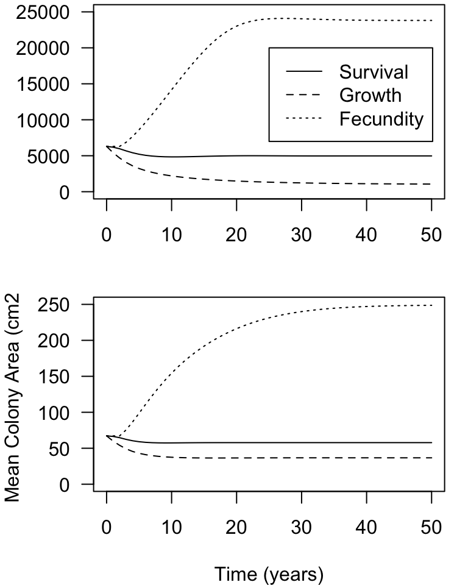

```r
par(mar=c(4,4,0.2,1),mfrow=c(2,1))
plot(0:years,mean_area_s_set_branch,type='l',las=1,ylim=c(0,25000),xlab='', ylab= '')
lines(0:years,mean_area_g_set_branch,type='l',lty=2)
lines(0:years,mean_area_p_set_branch,type='l',lty=3)
legend(x= 25, y = 20000, legend=c('Survival','Growth','Fecundity'),lty=c(1,2,3))

plot(0:years,mean_area_s_set_mass,type='l',las=1,ylim=c(0,250),xlab='Time (years)', ylab= 'Mean Colony Area (cm2)')
lines(0:years,mean_area_g_set_mass,type='l',lty=2)
lines(0:years,mean_area_p_set_mass,type='l',lty=3)
```